# Quantifier/Degree-modifier constructions

Stefan Hartmann, Jakob Neels, Tobias Ungerer

8/2/2021

## Preliminaries

First we load some packages – two of them, *concordances* and *collostructions*, are not on CRAN and can therefore not be installed via `install.packages`. *collostructions* is available [on Susanne Flach’s website](https://sfla.ch/collostructions/), *concordances* is available on [Github](https://hartmast.github.io/concordances/) and can be installed using `devtools::install_github` (package `devtools` needs to be installed; if it is not installed yet, you can install it from CRAN.)

```r
# install concordances package (if not yet installed)
if(!is.element("concordances", installed.packages())) {
  devtools::install_github("hartmast/concordances")
}

# load packages
library(collostructions) # available at sfla.ch
library(concordances)
library(tidyverse)
library(data.table)
library(ggraph)
library(igraph)
library(networkD3)
library(DT)
library(readxl)
```

## Queries

We used [DECOW](https://www.webcorpora.org/) to search for quantifier/degree-modifier constructions. The following queries were used (followed by the number of matches):

```r
# list of files
f <- list.files(pattern = "xml")

# get queries from concordance file:
sapply(1:length(f), function(i) trimws(gsub("<query>|</query>", "", readLines(f[i], n = 7)[6])))
```

```
##  [1] "[word=\"ein(e[nm])?\"] [word=\"[F]ünkchen\"] [tag=\"N.*|ADJ.*|V.*\"] 2948"
##  [2] "[word=\"ein(e[nm])?\"] [word=\"[F]ünkchen\"] \"zu\" [] 10"
##  [3] "[word=\"[eE]in(e[nm])?\"] [word=\"[Qq]u[eä]ntchen\"] [tag=\"N.*|ADJ.*|V.*\"] 3423"
##  [4] "[word=\"[Ee]in(e[mn])?\"] [word=\"[Hh]auch\"] [tag=\"N.*|ADJ.*\"] 16716"
##  [5] "[word=\"[Ee]in(e[mn])?\"] [word=\"[Hh]auch\"] \"zu\" [] 781"
##  [6] "[word=\"[eE]in(e[nm])?\"] [word=\"[Qq]u[eä]ntchen\"] \"zu\" [] 76"
##  [7] "[word=\"[Ee]in(e[nm])?\"] [word=\"[ZTzt]acken\"] [tag=\"N.*|ADJ.*\"] 1830"
##  [8] "[word=\"[Ee]in(e[nm])?\"] [word=\"[ZTzt]acken\"] \"zu\" [] 392"
##  [9] "[word=\"[Ee]in(e[mn])?\"] [word=\"[Tt]ick\"] [tag=\"ADJ.*|N.*\"] 17707"
## [10] "[word=\"[Ee]in(e[nm])?\"] [word=\"[Tt]ick\"] [word=\"zu\"] [] 6032"
## [11] "[word=\"[Ee]iner?\"] [word=\"[Hh]andvoll\"] [tag=\"N.*\"] 35998"
## [12] "[word=\"[Ee]iner?\"] [word=\"[Ii]dee\"] [tag=\"N.*|ADJ.*\"] 3900"
## [13] "[word=\"[Ee]iner?\"] [word=\"[Id]dee\"] \"zu\" [tag=\"ADJ.*\"] 349"
## [14] "[word=\"[Ee]iner?\"] [word=\"[Ss]pur\"] [tag=\"N.*|ADJ.*\"] 11192"
## [15] "[word=\"[Ee]iner?\"] [word=\"[Ss]pur\"] \"zu\" [tag=\"ADJ.*\"] 3442"
```

## Read in data

We use the concordances package to read in the data.

```r
# read data ---------------------------------------------------------------

fuenk <- getNSE("ein_em_Fuenkchen_ADJ_N.xml", xml = T, tags = T, context_tags = F, verbose = T)
fuenk_zu <- getNSE("ein_em_Fuenkchen_zu.xml", xml = T, tags = T, context_tags = F, verbose = T)
tack_zack <- getNSE("ein_enm_Tacken_Zacken_N_ADJ.xml", xml = T, context_tags = F)
tack_zack_zu <- getNSE("ein_enm_Tacken_Zacken_zu.xml", xml = T, context_tags = F)
handvoll <- getNSE("eine_r_Handvoll_ADJ_N.xml", xml = T, context_tags = F, tags = T)
idee <- getNSE("eine_r_Idee_ADJ_N.xml", xml = T, context_tags = F, tags = T)
idee_zu <- getNSE("eine_r_Idee_zu_ADJ.xml", xml = T, context_tags = F, tags = T)
tick <- getNSE("ein_enm_Tick_ADJ_N.xml", xml = T, context_tags = F, tags = T)
tick_zu <- getNSE("ein_enm_Tick_zu.xml", xml = T, context_tags = F, tags = T)
bisschen <- fread("ein_bisschen_adj_n_frequency_list.txt", col.names = c("Token", "Freq", "bla"))
hauch <- getNSE("ein_enm_Hauch_ADJ_N.xml", xml = T, context_tags = F, tags = T)
hauch_zu <- getNSE("ein_enm_Hauch_zu.xml", xml = T, context_tags = F, tags = T)
spur <- getNSE("eine_r_Spur_N_Adj.xml", xml = T, context_tags = F, tags = T)
spur_zu <- getNSE("eine_r_Spur_zu_ADJ.xml", xml = T, context_tags = F, tags = T)
quaentchen <- getNSE("ein_emn_Quäentchen_N_ADJ_V.xml", xml = T, context_tags = F, tags = T)
quaentchen_zu <- getNSE("ein_enm_Quäentchen_zu.xml", xml = T, context_tags = F, tags = T)
```

## Data wrangling

We write and use a function to remove duplicates; we combine the concordances for “ein(e) X ADJ/N” and “ein(e) X zu ADJ”; and we add a lemma column to each concordance (using the automatic annotation).

```r
# function for removing duplicates -----------
remove_duplicates <- function(df) {
  x <- which(duplicated(df$Left) &&
               duplicated(df$Key) &&
               duplicated(df$Right))

  if(length(x) > 0) {
    df <- df[-x,]
  }

  return(df)

}

# get modified nouns and adjectives in
# "bisschen" dataframe
bisschen[, Lemma := gsub("ein bisschen ", "", bisschen$Token)]

# remove duplicates
idee <- remove_duplicates(idee)
tick <- remove_duplicates(tick)
handvoll <- remove_duplicates(handvoll)
tack_zack <- remove_duplicates(tack_zack)
fuenk <- remove_duplicates(fuenk)
hauch <- remove_duplicates(hauch)
spur <- remove_duplicates(spur)
idee_zu <- remove_duplicates(idee_zu)
tick_zu <- remove_duplicates(tick_zu)
tack_zack_zu <- remove_duplicates(tack_zack_zu)
fuenk_zu <- remove_duplicates(fuenk_zu)
hauch_zu <- remove_duplicates(hauch_zu)
spur_zu <- remove_duplicates(spur_zu)
quaentchen <- remove_duplicates(quaentchen)
quaentchen_zu <- remove_duplicates(quaentchen_zu)

# combine "zu" and "normal" ones:
idee <- rbind(mutate(idee), cxn_type = "ADJ_N",
      mutate(idee_zu), cxn_type = "zu_ADJ")
spur <- rbind(mutate(spur), cxn_type = "ADJ_N",
              mutate(spur_zu), cxn_type = "zu_ADJ")
fuenk <- rbind(mutate(fuenk), cxn_type = "ADJ_N",
              mutate(fuenk_zu), cxn_type = "zu_ADJ")
spur <- rbind(mutate(spur), cxn_type = "ADJ_N",
              mutate(spur_zu), cxn_type = "zu_ADJ")
tack_zack <- rbind(mutate(tack_zack), cxn_type = "ADJ_N",
              mutate(tack_zack_zu), cxn_type = "zu_ADJ")
tick <- rbind(mutate(tick), cxn_type = "ADJ_N",
              mutate(tick_zu), cxn_type = "zu_ADJ")
hauch <- rbind(mutate(hauch), cxn_type = "ADJ_N",
              mutate(hauch_zu), cxn_type = "zu_ADJ")
quaentchen <- rbind(mutate(quaentchen), cxn_type = "ADJ_N",
                    mutate(quaentchen_zu), cxn_type = "zu_ADJ")


# add lemma column
idee$Lemma <- last_left(idee, Tag3_Key, 1)
tick$Lemma <- last_left(tick, Tag3_Key, 1)
fuenk$Lemma <- last_left(fuenk, Tag3_Key, 1)
tack_zack$Lemma <- last_left(tack_zack, Tag3_Key, 1)
handvoll$Lemma <- last_left(handvoll, Tag3_Key, 1)
spur$Lemma <- last_left(spur, Tag3_Key, 1)
hauch$Lemma <- last_left(hauch, Tag3_Key, 1)
quaentchen$Lemma <- last_left(quaentchen, Tag3_Key, 1)
```

In the case of Idee, there are still many false hits, so we export it for annotation…

```r
# write_csv(idee, "idee_for_anno.csv")

# Hauch: add last_left of keyword
# hauch$Key_modified <- last_left(hauch$Key, n = 1, omit_punctuation = FALSE)

# spur$Key_modified <- last_left(spur$Key, n = 1, omit_punctuation = FALSE)

# write_csv(hauch, "hauch_for_anno.csv")
# write_csv(spur, "spur_for_anno.csv")
```

We re-import the annotated datafiles:

```r
# import data
idee <- read_xlsx("idee_for_anno.xlsx")
hauch <- read_xlsx("hauch_for_anno.xlsx")
spur <- read_xlsx("spur_for_anno.xlsx")

# remove false hits
idee <- filter(idee, keep == "y")
hauch <- filter(hauch, Modifier == "y")
spur <- filter(spur, Modifier == "y")
```

We use the list of lemmas attested in the concordances to extract their total frequency in the DECOW corpus from the [DECOW lemma frequency list](https://www.webcorpora.org/opendata/frequencies/german/decow16b/).

```r
# list of all lemmas across dfs
lemmas_all <- c(idee$Lemma, tick$Lemma, fuenk$Lemma, tack_zack$Lemma,
  handvoll$Lemma, bisschen$Lemma, spur$Lemma, hauch$Lemma,
  quaentchen$Lemma) %>% unique


# collostructional analyses -----------------------------------------------
#
# read DECOW lemma frequencies
decow <- fread("/Volumes/TOSHIBA EXT/DECOW ngrams/decow16bx.lp.tsv")

# only keep verbs, nouns and adjectives
decow01 <- decow[V2 %in% c("NN", "ADJD", "ADJA", "VAINF", "VVFIN", "VVINF", "VAPP", "VVPP", "VVIZU", "VAIMP")]
colnames(decow01) <- c("lemma", "pos", "Freq")

# count POS
pos_tbl <- decow01 %>% group_by(pos) %>% summarise(
  Freq = sum(Freq)
)

# only keep lemmas attested in the constructions
decow <- decow01[lemma %in% lemmas_all]

# export
# saveRDS(decow, "decow_modifier_lemmas.Rds")
#saveRDS(pos_tbl, "pos_tbl.Rds")
```

```r
# re-import
decow <- readRDS("decow_modifier_lemmas.Rds")
pos_tbl <- readRDS("pos_tbl.Rds")
```

```r
# sum up frequencies of lemmas occuring more than once
decow_sum <- decow %>% group_by(lemma) %>% summarise(
  Freq = sum(Freq)
)
```

## Collostructional analysis

We have to do some more data wrangling in order to create the input dataframes for collostructional analysis.

```r
# frequency tables for the different constructions
idee_tbl <- idee %>% select(Lemma) %>% table %>% as.data.frame
fuenk_tbl <- fuenk %>% select(Lemma) %>% table %>% as.data.frame
handvoll_tbl <- handvoll %>%  select(Lemma) %>% table %>% as.data.frame
tick_tbl <- tick %>%  select(Lemma) %>% table %>% as.data.frame
tack_tbl <- tack_zack[grepl("Tacken", tack_zack$Key, ignore.case = T),] %>%
  select(Lemma) %>% table %>% as.data.frame
zack_tbl <- tack_zack[grepl("Zacken", tack_zack$Key, ignore.case = T),] %>%
  select(Lemma) %>% table %>% as.data.frame
hauch_tbl <- hauch %>%  select(Lemma) %>% table %>% as.data.frame
spur_tbl <- spur %>%  select(Lemma) %>% table %>% as.data.frame
quaentchen_tbl <- quaentchen %>% select(Lemma) %>% table %>% as.data.frame()

colnames(idee_tbl) <- colnames(fuenk_tbl) <-
  colnames(handvoll_tbl) <- colnames(tack_tbl) <-
  colnames(zack_tbl) <- colnames(tick_tbl) <-
  colnames(spur_tbl) <- colnames(hauch_tbl) <-
  colnames(quaentchen_tbl) <-
  c("lemma", "Freq_mod")

bisschen_tbl <- bisschen %>% group_by(Lemma) %>% summarise(
  Freq_bisschen = sum(Freq)
)
colnames(bisschen_tbl) <- c("lemma", "Freq_bisschen")

# join dataframes
idee_tbl <- left_join(idee_tbl, decow_sum)
fuenk_tbl <- left_join(fuenk_tbl, decow_sum)
handvoll_tbl <- left_join(handvoll_tbl, decow_sum)
tack_tbl <- left_join(tack_tbl, decow_sum)
tick_tbl <- left_join(tick_tbl, decow_sum)
zack_tbl <- left_join(zack_tbl, decow_sum)
spur_tbl <- left_join(spur_tbl, decow_sum)
hauch_tbl <- left_join(hauch_tbl, decow_sum)
quaentchen_tbl <- left_join(quaentchen_tbl, decow_sum)
bisschen_tbl <- left_join(bisschen_tbl, decow_sum)

# replace NAs by 0
idee_tbl <- replace_na(idee_tbl, list(Freq_mod = 0, Freq = 0))
fuenk_tbl <- replace_na(fuenk_tbl, list(Freq_mod = 0, Freq = 0))
handvoll_tbl <- replace_na(handvoll_tbl, list(Freq_mod = 0, Freq = 0))
tack_tbl <- replace_na(tack_tbl, list(Freq_mod = 0, Freq = 0))
tick_tbl <- replace_na(tick_tbl, list(Freq_mod = 0, Freq = 0))
zack_tbl <- replace_na(zack_tbl, list(Freq_mod = 0, Freq = 0))
hauch_tbl <- replace_na(hauch_tbl, list(Freq_mod = 0, Freq = 0))
spur_tbl <- replace_na(spur_tbl, list(Freq_mod = 0, Freq = 0))
quaentchen_tbl <- replace_na(quaentchen_tbl, list(Freq_mod = 0, Freq = 0))
bisschen_tbl <- replace_na(bisschen_tbl, list(Freq_bisschen = 0, Freq = 0))

# reomove cases where cxn frequency is bigger than
# corpus frequency
idee_tbl <- idee_tbl[which(idee_tbl$Freq_mod <= idee_tbl$Freq),]
fuenk_tbl <- fuenk_tbl[which(fuenk_tbl$Freq_mod <= fuenk_tbl$Freq),]
handvoll_tbl <- handvoll_tbl[which(handvoll_tbl$Freq_mod <= handvoll_tbl$Freq),]
tack_tbl <- tack_tbl[which(tack_tbl$Freq_mod <= tack_tbl$Freq),]
tick_tbl <- tick_tbl[which(tick_tbl$Freq_mod <= tick_tbl$Freq),]
zack_tbl <- zack_tbl[which(zack_tbl$Freq_mod <= zack_tbl$Freq),]
spur_tbl <- spur_tbl[which(spur_tbl$Freq_mod <= spur_tbl$Freq),]
hauch_tbl <- hauch_tbl[which(hauch_tbl$Freq_mod <= hauch_tbl$Freq),]
quaentchen_tbl <- quaentchen_tbl[which(quaentchen_tbl$Freq_mod <= quaentchen_tbl$Freq),]
bisschen_tbl <- bisschen_tbl[which(bisschen_tbl$Freq_bisschen <= bisschen_tbl$Freq),]


# collexeme analysis ------------------------------------------------------

col_idee <- collex(idee_tbl,
       corpsize =
         sum(pos_tbl[grep("ADJ.*", pos_tbl$pos),]$Freq))# %>%  write_excel_csv("idee_collex.csv")

col_fuenk <- collex(fuenk_tbl,
       corpsize = sum(pos_tbl$Freq)) # %>% write_excel_csv("fuenkchen_collex.csv")

col_handvoll <- collex(handvoll_tbl,
       corpsize = sum(pos_tbl$Freq)) # %>% write_csv("handvoll_collex.csv")

col_tack <- collex(tack_tbl,
       corpsize = sum(pos_tbl$Freq)) # %>% write_csv("tack_collex.csv")

col_tick <- collex(tick_tbl,
                   corpsize = sum(pos_tbl$Freq)) # %>% write_csv("tick_collex.csv")

col_zack <- collex(zack_tbl,
       corpsize = sum(pos_tbl$Freq)) # %>% write_csv("zack_collex.csv")

col_spur <- collex(spur_tbl,
                   corpsize = sum(pos_tbl$Freq)) # %>% write_csv("spur_collex.csv")


col_hauch <- collex(hauch_tbl,
                   corpsize = sum(pos_tbl$Freq)) # %>% write_csv("hauch_collex.csv")

col_quaentchen <- collex(quaentchen_tbl,
                    corpsize = sum(pos_tbl$Freq)) # %>% write_csv("quaentchen_collex.csv")


col_bisschen <- collex(bisschen_tbl,
                   corpsize = sum(pos_tbl$Freq)) # %>% write_csv("bisschen_collex.csv")
```

## Collostructional analysis: Results

### ein bisschen

|  | COLLEX | CORP.FREQ | OBS | EXP | ASSOC | COLL.STR.LOGL | SIGNIF |
| --- | --- | --- | --- | --- | --- | --- | --- |
| 1 | Glück | 1555384 | 6431 | 87.8 | attr | 42708.25945 | ***** |
| 2 | Zeit | 11707865 | 10074 | 661 | attr | 36382.21801 | ***** |
| 3 | komisch | 587585 | 3958 | 33.2 | attr | 30083.50296 | ***** |
| 4 | UFC | 16155 | 1800 | 0.9 | attr | 23936.71411 | ***** |
| 5 | Angst | 1544846 | 4045 | 87.2 | attr | 23190.05503 | ***** |
| 6 | Geld | 3467988 | 4482 | 195.8 | attr | 19562.28536 | ***** |
| 7 | Gameplay | 65922 | 1831 | 3.7 | attr | 19106.87553 | ***** |
| 8 | Geduld | 261290 | 2172 | 14.8 | attr | 17405.16138 | ***** |
| 9 | stolz | 550577 | 2402 | 31.1 | attr | 16172.90619 | ***** |
| 10 | traurig | 533593 | 2218 | 30.1 | attr | 14720.42416 | ***** |

[output cut: 7771 more lines]

### ein Hauch

|  | COLLEX | CORP.FREQ | OBS | EXP | ASSOC | COLL.STR.LOGL | SIGNIF |
| --- | --- | --- | --- | --- | --- | --- | --- |
| 1 | Vanille | 31412 | 287 | 0.1 | attr | 4045.42253 | ***** |
| 2 | Exotik | 6155 | 203 | 0 | attr | 3386.20803 | ***** |
| 3 | Nostalgie | 21777 | 162 | 0.1 | attr | 2215.24496 | ***** |
| 4 | Romantik | 69803 | 173 | 0.2 | attr | 1984.90614 | ***** |
| 5 | Ironie | 102463 | 173 | 0.3 | attr | 1852.15733 | ***** |
| 6 | Melancholie | 31502 | 137 | 0.1 | attr | 1725.71847 | ***** |
| 7 | Erotik | 57961 | 145 | 0.2 | attr | 1666.08503 | ***** |
| 8 | Zimt | 38906 | 117 | 0.1 | attr | 1387.2194 | ***** |
| 9 | Luxus | 126180 | 138 | 0.4 | attr | 1357.44274 | ***** |
| 10 | Knoblauch | 76675 | 100 | 0.2 | attr | 1018.54131 | ***** |

[output cut: 3837 more lines]

### eine Spur

|  | COLLEX | CORP.FREQ | OBS | EXP | ASSOC | COLL.STR.LOGL | SIGNIF |
| --- | --- | --- | --- | --- | --- | --- | --- |
| 1 | hart | 1237210 | 481 | 4.2 | attr | 3620.64583 | ***** |
| 2 | gut | 32699035 | 796 | 111 | attr | 1794.4054 | ***** |
| 3 | laut | 749427 | 228 | 2.5 | attr | 1602.0885 | ***** |
| 4 | heftig | 527517 | 176 | 1.8 | attr | 1268.30712 | ***** |
| 5 | dunkel | 847070 | 176 | 2.9 | attr | 1103.72461 | ***** |
| 6 | dick | 874131 | 151 | 3 | attr | 891.95044 | ***** |
| 7 | schnell | 6420257 | 267 | 21.8 | attr | 851.07692 | ***** |
| 8 | scharf | 512913 | 112 | 1.7 | attr | 712.91397 | ***** |
| 9 | glatt | 371870 | 103 | 1.3 | attr | 703.89034 | ***** |
| 10 | hell | 592236 | 113 | 2 | attr | 689.2972 | ***** |

[output cut: 2966 more lines]

### ein Zacken

|  | COLLEX | CORP.FREQ | OBS | EXP | ASSOC | COLL.STR.LOGL | SIGNIF |
| --- | --- | --- | --- | --- | --- | --- | --- |
| 1 | scharf | 512913 | 242 | 0.1 | attr | 3333.75189 | ***** |
| 2 | gut | 32699035 | 177 | 6.6 | attr | 854.14248 | ***** |
| 3 | hart | 1237210 | 64 | 0.2 | attr | 586.47155 | ***** |
| 4 | schnell | 6420257 | 77 | 1.3 | attr | 483.37382 | ***** |
| 5 | heftig | 527517 | 16 | 0.1 | attr | 128.84312 | ***** |
| 6 | schlimm | 1325094 | 17 | 0.3 | attr | 107.96134 | ***** |
| 7 | dazugefeilt | 2 | 2 | 0 | attr | 61.66454 | ***** |
| 8 | aggressiv | 229046 | 7 | 0 | attr | 56.41207 | ***** |
| 9 | trendig | 36650 | 5 | 0 | attr | 55.19437 | ***** |
| 10 | teuer | 1410066 | 10 | 0.3 | attr | 51.83527 | ***** |

[output cut: 238 more lines]

### ein Tick

|  | COLLEX | CORP.FREQ | OBS | EXP | ASSOC | COLL.STR.LOGL | SIGNIF |
| --- | --- | --- | --- | --- | --- | --- | --- |
| 1 | gut | 32699035 | 5716 | 145 | attr | 32417.49796 | ***** |
| 2 | schnell | 6420257 | 1998 | 28.5 | attr | 13231.06443 | ***** |
| 3 | dunkel | 847070 | 439 | 3.8 | attr | 3318.83978 | ***** |
| 4 | hell | 592236 | 408 | 2.6 | attr | 3314.55319 | ***** |
| 5 | langsam | 1769254 | 481 | 7.8 | attr | 3023.80411 | ***** |
| 6 | spät | 4601178 | 593 | 20.4 | attr | 2866.39587 | ***** |
| 7 | lang | 6584034 | 564 | 29.2 | attr | 2283.8274 | ***** |
| 8 | stark | 4713188 | 441 | 20.9 | attr | 1857.59199 | ***** |
| 9 | laut | 749427 | 247 | 3.3 | attr | 1643.93149 | ***** |
| 10 | scharf | 512913 | 197 | 2.3 | attr | 1370.26964 | ***** |

[output cut: 1748 more lines]

### ein Tacken

|  | COLLEX | CORP.FREQ | OBS | EXP | ASSOC | COLL.STR.LOGL | SIGNIF |
| --- | --- | --- | --- | --- | --- | --- | --- |
| 1 | gut | 32699035 | 292 | 6.9 | attr | 1706.26811 | ***** |
| 2 | schnell | 6420257 | 60 | 1.3 | attr | 341.51761 | ***** |
| 3 | dunkel | 847070 | 33 | 0.2 | attr | 280.12533 | ***** |
| 4 | hell | 592236 | 24 | 0.1 | attr | 205.40224 | ***** |
| 5 | günstig | 1608061 | 21 | 0.3 | attr | 132.55336 | ***** |
| 6 | hart | 1237210 | 19 | 0.3 | attr | 125.96317 | ***** |
| 7 | schlimm | 1325094 | 15 | 0.3 | attr | 90.38201 | ***** |
| 8 | scharf | 512913 | 12 | 0.1 | attr | 89.46886 | ***** |
| 9 | teuer | 1410066 | 13 | 0.3 | attr | 73.07885 | ***** |
| 10 | leise | 455718 | 9 | 0.1 | attr | 64.05559 | ***** |

[output cut: 244 more lines]

### eine Handvoll

|  | COLLEX | CORP.FREQ | OBS | EXP | ASSOC | COLL.STR.LOGL | SIGNIF |
| --- | --- | --- | --- | --- | --- | --- | --- |
| 1 | Leute | 3849975 | 1910 | 25.5 | attr | 12826.45557 | ***** |
| 2 | Dollar | 401953 | 801 | 2.7 | attr | 7565.20236 | ***** |
| 3 | Mensch | 10308206 | 1081 | 68.3 | attr | 3976.13746 | ***** |
| 4 | Nuss | 96779 | 196 | 0.6 | attr | 1853.87975 | ***** |
| 5 | Erde | 1073388 | 274 | 7.1 | attr | 1469.16304 | ***** |
| 6 | Reis | 123548 | 166 | 0.8 | attr | 1434.17919 | ***** |
| 7 | Spieler | 1989833 | 260 | 13.2 | attr | 1058.50576 | ***** |
| 8 | Mann | 4288435 | 316 | 28.4 | attr | 949.51359 | ***** |
| 9 | Rosine | 23909 | 82 | 0.2 | attr | 861.60893 | ***** |
| 10 | Sand | 329160 | 133 | 2.2 | attr | 832.24057 | ***** |

[output cut: 7774 more lines]

### ein Fünkchen

|  | COLLEX | CORP.FREQ | OBS | EXP | ASSOC | COLL.STR.LOGL | SIGNIF |
| --- | --- | --- | --- | --- | --- | --- | --- |
| 1 | Wahrheit | 786653 | 890 | 0.5 | attr | 12010.29414 | ***** |
| 2 | Hoffnung | 813027 | 679 | 0.5 | attr | 8689.96335 | ***** |
| 3 | Verstand | 222498 | 71 | 0.1 | attr | 755.82865 | ***** |
| 4 | Anstand | 35354 | 31 | 0 | attr | 392.19484 | ***** |
| 5 | Humor | 251941 | 32 | 0.1 | attr | 281.43079 | ***** |
| 6 | Ahnung | 718130 | 27 | 0.4 | attr | 172.25325 | ***** |
| 7 | Interesse | 2108621 | 32 | 1.2 | attr | 147.58746 | ***** |
| 8 | Glück | 1555384 | 29 | 0.9 | attr | 145.25461 | ***** |
| 9 | Mitleid | 88580 | 14 | 0.1 | attr | 129.13581 | ***** |
| 10 | Menschlichkeit | 63222 | 12 | 0 | attr | 115.05974 | ***** |

[output cut: 494 more lines]

### eine Idee

|  | COLLEX | CORP.FREQ | OBS | EXP | ASSOC | COLL.STR.LOGL | SIGNIF |
| --- | --- | --- | --- | --- | --- | --- | --- |
| 1 | gut | 32699035 | 202 | 33.6 | attr | 414.50673 | ***** |
| 2 | lang | 6584034 | 54 | 6.8 | attr | 131.84804 | ***** |
| 3 | schnell | 6420257 | 49 | 6.6 | attr | 113.30062 | ***** |
| 4 | tief | 1593236 | 22 | 1.6 | attr | 73.95994 | ***** |
| 5 | hoch | 7853481 | 41 | 8.1 | attr | 68.39122 | ***** |
| 6 | scharf | 512913 | 13 | 0.5 | attr | 58.53545 | ***** |
| 7 | hell | 592236 | 13 | 0.6 | attr | 54.95787 | ***** |
| 8 | dunkel | 847070 | 14 | 0.9 | attr | 51.67591 | ***** |
| 9 | groß | 16565986 | 53 | 17 | attr | 49.59689 | ***** |
| 10 | breit | 1297893 | 15 | 1.3 | attr | 45.43919 | ***** |

[output cut: 346 more lines]

### ein Quäntchen

|  | COLLEX | CORP.FREQ | OBS | EXP | ASSOC | COLL.STR.LOGL | SIGNIF |
| --- | --- | --- | --- | --- | --- | --- | --- |
| 1 | Glück | 1555384 | 955 | 1 | attr | 11438.60372 | ***** |
| 2 | Wahrheit | 786653 | 193 | 0.5 | attr | 1907.82522 | ***** |
| 3 | Humor | 251941 | 48 | 0.2 | attr | 448.13878 | ***** |
| 4 | Hoffnung | 813027 | 58 | 0.5 | attr | 428.38462 | ***** |
| 5 | gut | 32699035 | 168 | 21.8 | attr | 400.9362 | ***** |
| 6 | Trost | 107352 | 30 | 0.1 | attr | 302.84507 | ***** |
| 7 | Mut | 439989 | 34 | 0.3 | attr | 256.26565 | ***** |
| 8 | Ironie | 102463 | 23 | 0.1 | attr | 222.0798 | ***** |
| 9 | Selbstironie | 11149 | 13 | 0 | attr | 168.27232 | ***** |
| 10 | glücken | 35372 | 13 | 0 | attr | 138.27519 | ***** |

[output cut: 1022 more lines]

## Number of shared collexemes

While the collexeme analyses give an impression of the semantics of each construction, another interesting question is how many of the collexemes are shared between the individual constructions. In order to assess this question, we create a word-construction-matrix and visualize it using a heatmap.

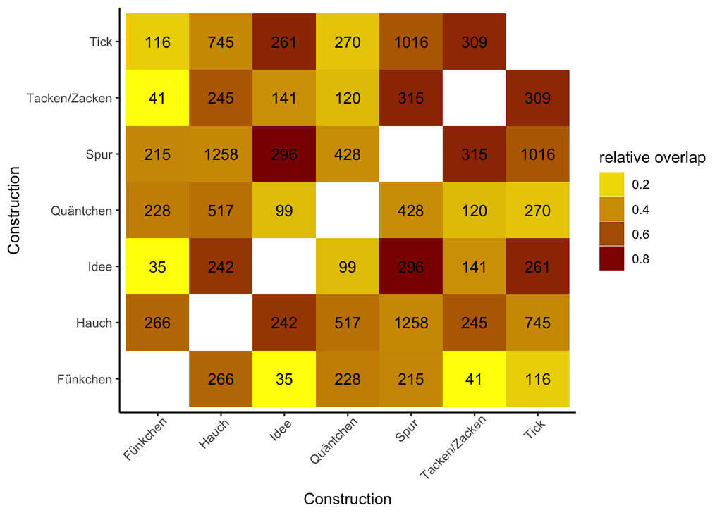

```r
# create long list of lemmas and cxns
lemmas_df <- rbind(
  mutate(select(fuenk, Lemma), cxn = "Fünkchen"),
  mutate(select(hauch, Lemma), cxn = "Hauch"),
  mutate(select(idee, Lemma), cxn = "Idee"),
  mutate(select(quaentchen, Lemma), cxn = "Quäntchen"),
  mutate(select(spur, Lemma), cxn = "Spur"),
  mutate(select(tack_zack, Lemma), cxn = "Tacken/Zacken"),
  mutate(select(tick, Lemma), cxn = "Tick")
)

# find out how many items are shared between each 2 cxns
cxns <- unique(lemmas_df$cxn)

# empty dataframe
mydf <- data.frame(matrix(NA, nrow = 7, ncol = 7))
colnames(mydf) <- cxns
rownames(mydf) <- cxns

for(i in 1:length(cxns)) {
  for(j in 1:length(cxns)) {
    mydf[j,i] <- length(intersect(filter(lemmas_df, cxn == colnames(mydf)[i])$Lemma,
          filter(lemmas_df, cxn == rownames(mydf)[j])$Lemma))

  }
}


# change to long dataframe
mydf2 <- rownames_to_column(mydf)
mydf_long <- pivot_longer(mydf2, 2:length(mydf2))
colnames(mydf_long) <- c("cxn_A", "cxn_B", "n")

# get a more reliable impression of the number of shared items by dividing the frequency value by the total number of types of the less frequent construction

mytypes <- lemmas_df %>% group_by(cxn) %>% summarise(
  types = length(unique(Lemma))
)

# add n of types for cxn A and B
mydf_long <- left_join(mydf_long, mytypes, by = c("cxn_A" = "cxn"))
mydf_long <- rename(mydf_long, types_A = types)
mydf_long <- left_join(mydf_long, mytypes, by = c("cxn_B" = "cxn"))
mydf_long <- rename(mydf_long, types_B = types)

# get smaller n
mydf_long$n_min_types <- ifelse(mydf_long$types_A < mydf_long$types_B, mydf_long$types_A, mydf_long$types_B)

# "relative" frequency
mydf_long$rel <- mydf_long$n / mydf_long$n_min_types


# heatmap
mydf_long %>% filter(rel < 1) %>% ggplot(aes(x = cxn_A, y = cxn_B, fill = rel, label = n)) + geom_tile() + geom_text() + scale_fill_gradient(low = "yellow", high = "darkred") +
  xlab("Construction") + ylab("Construction") + guides(fill = guide_legend(title = "relative overlap")) + theme_classic() + theme(axis.text.x = element_text(angle=45, hjust=.9))
```

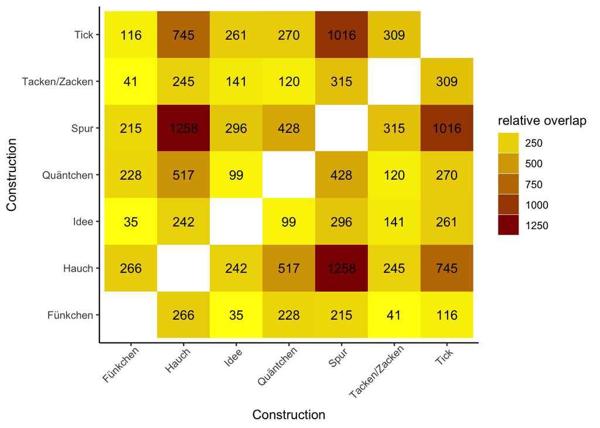

```r
mydf_long %>% filter(rel < 1) %>% ggplot(aes(x = cxn_A, y = cxn_B, fill = n, label = n)) + geom_tile() + geom_text() + scale_fill_gradient(low = "yellow", high = "darkred") +
  xlab("Construction") + ylab("Construction") + guides(fill = guide_legend(title = "relative overlap")) + theme_classic() + theme(axis.text.x = element_text(angle=45, hjust=.9))
```

## References

- Schäfer, Roland. 2015. Processing and querying large corpora with the COW14 architecture. In Piotr Bański, Hanno Biber, Evelyn Breiteneder, Marc Kupietz, Harald Lüngen & Andreas Witt (eds.), Challenges in the Management of Large Corpora (CMLC-3), 28–34.
- Schäfer, Roland & Felix Bildhauer. 2012. Building Large Corpora from the Web Using a New Efficient Tool Chain. In Nicoletta Calzolari, Khalid Choukri, Terry Declerck, Mehmet Uğur Doğan, Bente Maegaard, Joseph Mariani, Asuncion Moreno, Jan Odijk & Stelios Piperidis (eds.), Proceedings of LREC 2012, 486–493.